# Quan_Tech_Areal_Data_Exam

Auriel Fournier

Monday, March 16, 2015

Much of the code has been hidden from the html output for readability.

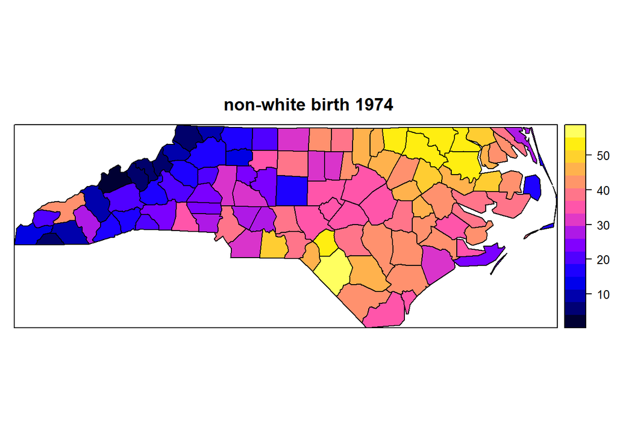

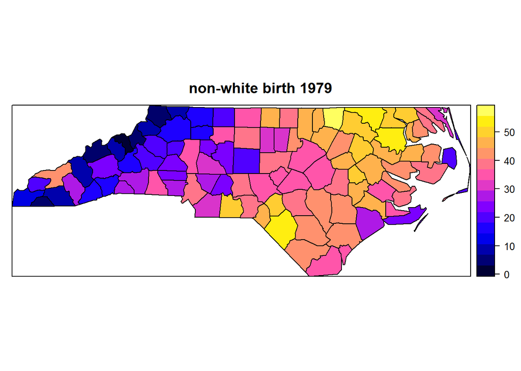

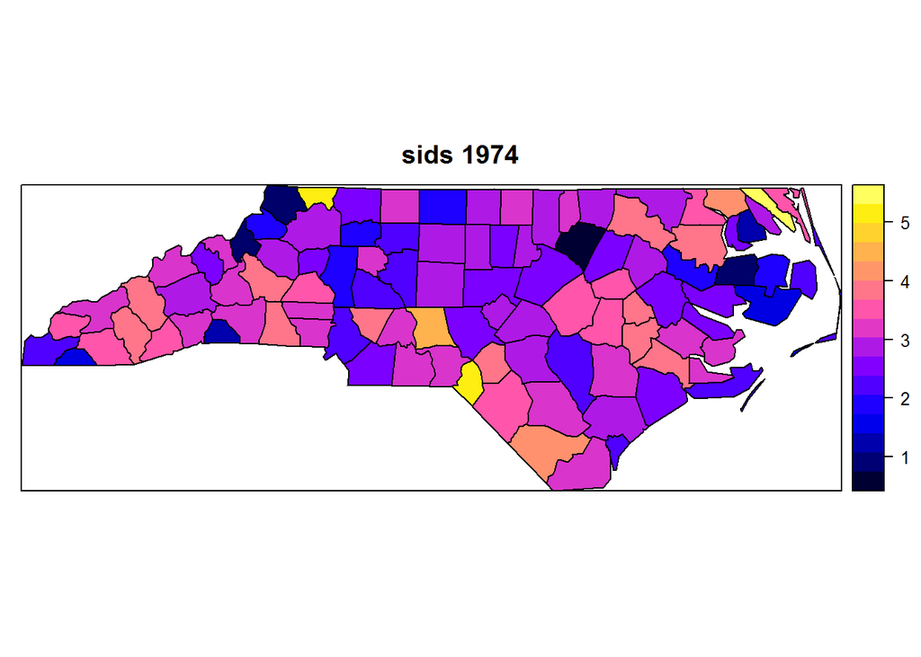

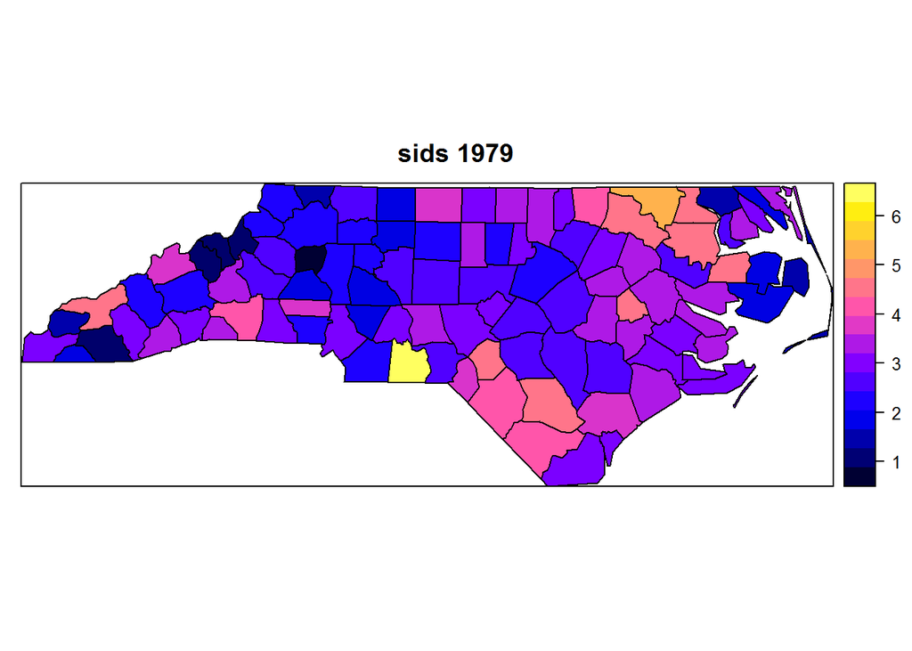

```r
library(ggplot2)
library(maptools)
library(spdep)
library(xtable)
library(sp)
```

While the non white birth rate does not appear to change much between the two years the sids rate declines over all from 1974-1979 though the hot spots are still in the same parts of the state, though not always the same counties.

First I’d like to examine any relationship between these two variables without taking into account spatial variation. I’ll do this by running a linear model of non-white births vs sids.

```
##
## Call:
## lm(formula = nwbir74ft ~ sid74ft, data = nc.sids)
##
## Residuals:
##     Min      1Q  Median      3Q     Max
## -29.547 -11.057   2.296  10.874  22.012
##
## Coefficients:
##             Estimate Std. Error t value Pr(>|t|)
## (Intercept)   25.123      4.833   5.198  1.1e-06 ***
## sid74ft        2.539      1.595   1.592    0.115
## ---
## Signif. codes:  0 '***' 0.001 '**' 0.01 '*' 0.05 '.' 0.1 ' ' 1
##
## Residual standard error: 13.62 on 98 degrees of freedom
## Multiple R-squared:  0.02521,    Adjusted R-squared:  0.01526
## F-statistic: 2.534 on 1 and 98 DF,  p-value: 0.1146
```

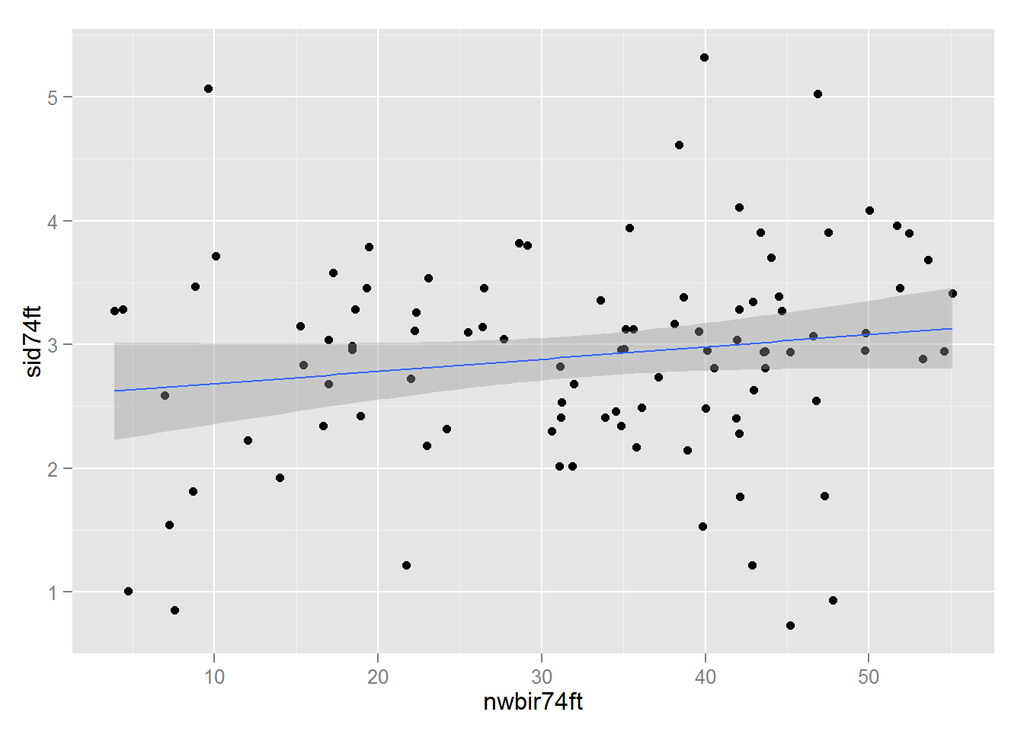

```
##
## Call:
## lm(formula = nwbir79ft ~ sid79ft, data = nc.sids)
##
## Residuals:
##     Min      1Q  Median      3Q     Max
## -32.975  -8.848   3.054   7.730  27.899
##
## Coefficients:
##             Estimate Std. Error t value Pr(>|t|)
## (Intercept)    8.564      3.543   2.417   0.0175 *
## sid79ft        8.275      1.157   7.155 1.53e-10 ***
## ---
## Signif. codes:  0 '***' 0.001 '**' 0.01 '*' 0.05 '.' 0.1 ' ' 1
##
## Residual standard error: 11.23 on 98 degrees of freedom
## Multiple R-squared:  0.3431, Adjusted R-squared:  0.3364
## F-statistic: 51.19 on 1 and 98 DF,  p-value: 1.533e-10
```

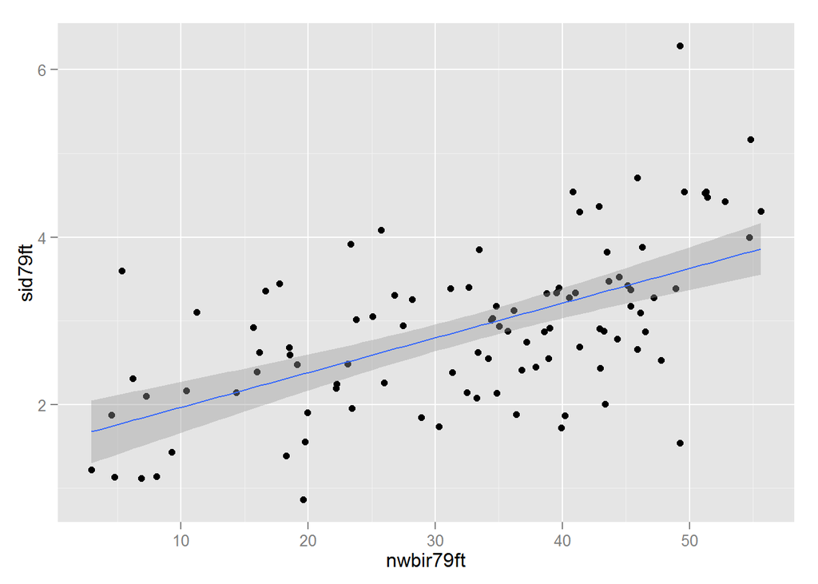

So in 1979 there is a significant relationship between the two, but not in 1974. In both cases the R is low (1979 it is .3431) suggesting that even when it is significant there might be other factors at play.

So lets start to examine things spatially.

```r
col.qb <- nb2listw(poly2nb(nc.sids, queen=T),style="B")
col.rw <- nb2listw(poly2nb(nc.sids, queen=F),style="W")
col.rb <- nb2listw(poly2nb(nc.sids, queen=F),style="B")
coords <- coordinates(nc.sids)
nc.d2 <- nb2listw(dnearneigh(coords, d1=0, d=2))
nc.d1 <- nb2listw(dnearneigh(coords, d1=0, d=1))
knn1 <- nb2listw(knn2nb(knearneigh(coords, k=1)))
knn2 <- nb2listw(knn2nb(knearneigh(coords, k=2)))
knn3 <- nb2listw(knn2nb(knearneigh(coords, k=3)))
knn4 <- nb2listw(knn2nb(knearneigh(coords, k=4)))
knn5 <- nb2listw(knn2nb(knearneigh(coords, k=5)))
knn6 <- nb2listw(knn2nb(knearneigh(coords, k=6)))
knn7 <- nb2listw(knn2nb(knearneigh(coords, k=7)))
knn8 <- nb2listw(knn2nb(knearneigh(coords, k=8)))
knn9 <- nb2listw(knn2nb(knearneigh(coords, k=9)))
knn10 <- nb2listw(knn2nb(knearneigh(coords, k=10)))
knn20 <- nb2listw(knn2nb(knearneigh(coords, k=20)))
knn30 <- nb2listw(knn2nb(knearneigh(coords, k=30)))
```

### 1974

```
##     Names Observed Moran's I  Expectation     Variance
## 4   nc.d2          0.5265788 -0.010020618 0.0003137188
## 17  knn30          0.5627748 -0.009980457 0.0004085248
## 16  knn20          0.6179374 -0.010045452 0.0007102911
## 5   nd.d1          0.6343964 -0.010062152 0.0011981431
## 1  col.qb          0.6745137 -0.011239995 0.0038299674
## 3  col.rb          0.6815243 -0.011507868 0.0040892687
## 15  knn10          0.6841310 -0.010328769 0.0016391118
## 14   knn9          0.6944897 -0.010445549 0.0018442993
## 10   knn5          0.7007027 -0.011230610 0.0034341086
## 11   knn6          0.7037435 -0.010891495 0.0028563442
## 13   knn8          0.7043062 -0.010546185 0.0020993996
## 12   knn7          0.7097198 -0.010886501 0.0024147708
## 9    knn4          0.7263582 -0.010964629 0.0043598222
## 8    knn3          0.7403804 -0.011312599 0.0059041044
## 6    knn1          0.7416131 -0.012597687 0.0148741947
## 2  col.rw          0.7421808 -0.011725012 0.0044682526
## 7    knn2          0.7702663 -0.012006722 0.0085670587
```

### 1979

```
##     Names Observed Moran's I Expectation     Variance
## 4   nc.d2          0.4295463 -0.01102507 0.0002763484
## 17  knn30          0.4346759 -0.01138426 0.0003611534
## 6    knn1          0.4781801 -0.01451673 0.0148945768
## 3  col.rb          0.4934032 -0.01273419 0.0040261304
## 16  knn20          0.4948162 -0.01173555 0.0006619085
## 1  col.qb          0.4955004 -0.01246842 0.0037833654
## 5   nd.d1          0.5104433 -0.01191525 0.0011523389
## 9    knn4          0.5212247 -0.01267656 0.0043188931
## 11   knn6          0.5212701 -0.01239808 0.0028066664
## 10   knn5          0.5237032 -0.01233118 0.0033861981
## 15  knn10          0.5261396 -0.01204413 0.0015861664
## 14   knn9          0.5264196 -0.01205059 0.0017925279
## 12   knn7          0.5328092 -0.01224801 0.0023609457
## 13   knn8          0.5345926 -0.01229564 0.0020478836
## 8    knn3          0.5350312 -0.01272175 0.0058789835
## 7    knn2          0.5385829 -0.01340789 0.0085426953
## 2  col.rw          0.5538677 -0.01276221 0.0044131882
```

This suggests that the clustering is happening at the small scale in both situations.

I made the following two graphs after reading section 7.5 in O’Sullivan and Unwin (2010) and seeing Figure 7.10 which showed a graphical way of seeing how many neighbors are an appropriate scale. I thought this might help in my own analysis but as you can see instead of drop off after 3 neighbors as is seen in O’Sullivan and Unwin (2010) it is straight line, with a fairly high spread of values and several outliers. So this was not informative for the number of neighbors to cut it off at. The fact that the values are roughly the same at each number of neighbors suggests that there may not be clumping, unless the clumping is larger then 10. Originally I picked 1-10 numbers and there was no difference, so then I added 20 and 30 to see if the trend continued, and as you can see, it does. though data is tighter. I feel that cutting off the number of neighbors at 30 is appropriate since that is ~30% of the data.

### 1979

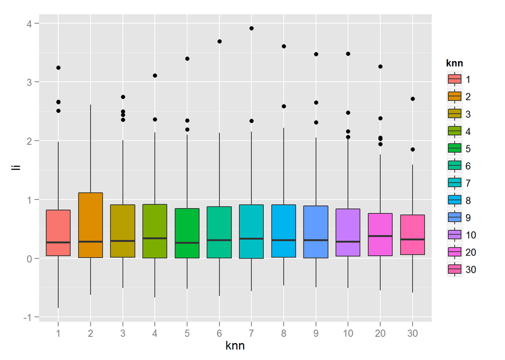

### 1974

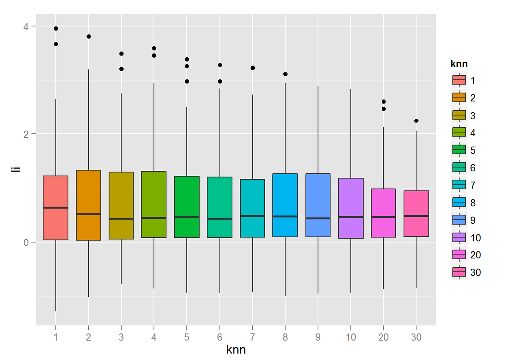

The first problem, as we saw before is that for 1974 non-white birth is not significant at explaining sids, and for 1979 it is significant, but the R^2 is so low that it isn’t explaining most of the variation in the data. breaking the state up into a large grid of counties doesn’t make sense to me conceptually, since those boundaries are totally arbitrary, it seems like we would be better off examining more kinds of neighbor relationships between counties instead of plopping them into boxes.

### KNN1 1974

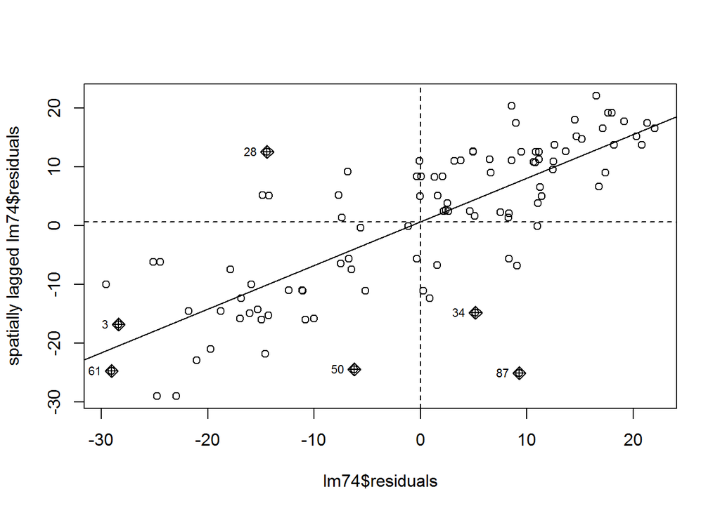

### rook row normalized 1974

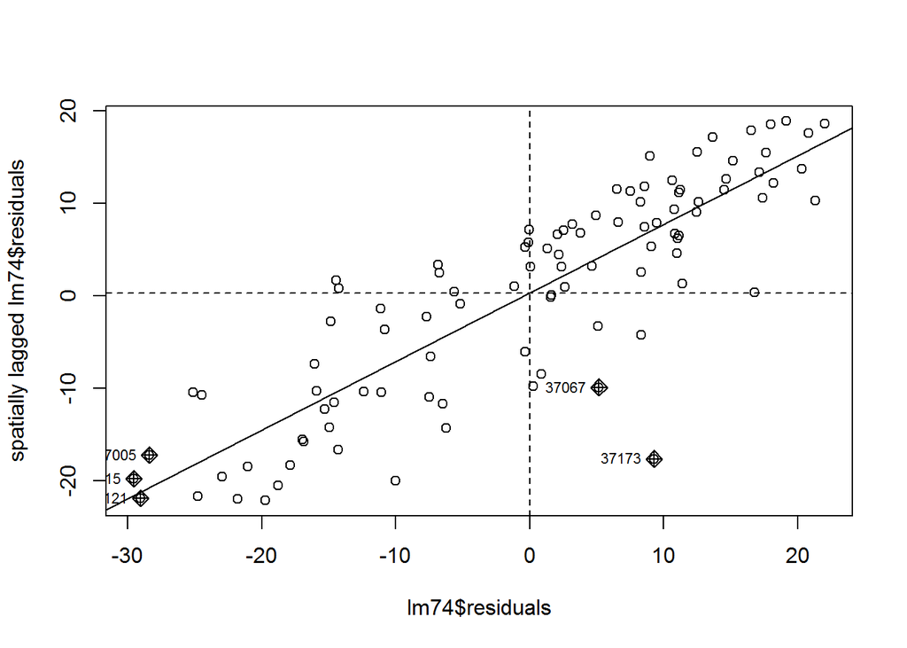

Looking at both the Moran’s plots for 1974 shows that counties tend to have sids rates like the counties around them, either clustering above or below the mean. There are a few outliers in both cases, in the rook row normalized there are two in the lower right hand corner which means they were unusually high compared to their neighbors. Looking at non-white births is one layer of this puzzle but looking at income or some metric of educational level might also be informative to take more of the noise out of these graphs.

### KNN1 1979

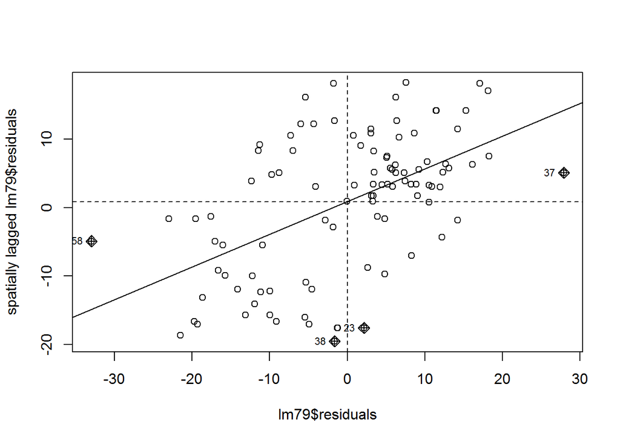

### rook row normalized 1979

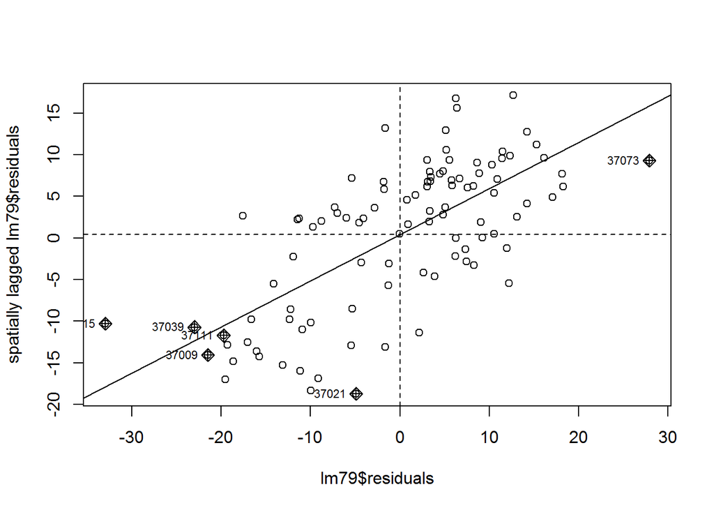

The 1979 Moran’s plots are more diffuse, with more points occurring in the upper left and lower right boxes, suggesting that there is more heterogeneity on the landscape, since areas in these quadrants are not like their neighbors, they are either low when their neighbors are high (upper left) or vise versa (lower right).

## Discussion

From what I can tell there is clustering of sids cases in North Carolina and in 1979 non-white birth rate might explain that trend, atleast in part, but in both cases I think something bigger might be driving it.

I would suggest the inclusion of another variable, perhaps related to education, or to educational campaigns done by health departments or other organizations about SIDS, and seeing if that explains any more of the variation.

I apologize that I was not able to give this the time I should have, but I didn’t, and that is my fault for managing my time poorly, but some other things had to take priority this week.

Bibliography

O’Sullivan, David., and David J. Unwin. 2010. *Geographic Information Analysis*. Wiley.